# Tarea 3 - Estadística Espacial

Brayan Cubides - Sebastian Gil - Andrés Rache - Dereck Rozo

2024-03-03

# Punto 1

```r
set.seed(12345)

n <- 100
sigma <- 1
phi <- 2

# Define la matriz de distancias
dist_matrix <- matrix(0, n, n)
for (i in 1:n) {
  for (j in 1:n) {
    dist_matrix[i, j] <- abs(i - j)}}

# Define la función de covarianza exponencial
cov_exponential <- function(h, sigma, phi) {
  return(sigma^2 * exp(-h / phi))}

Sigma <- cov_exponential(dist_matrix, sigma, phi) #matriz de covarianza

mu <- rep(0, n) #Vector de medias

# Simula un proceso gaussiano
set.seed(123)
simulated_data <- rmvnorm(1, mean = mu, sigma = Sigma)

# View(simulated_data)
```

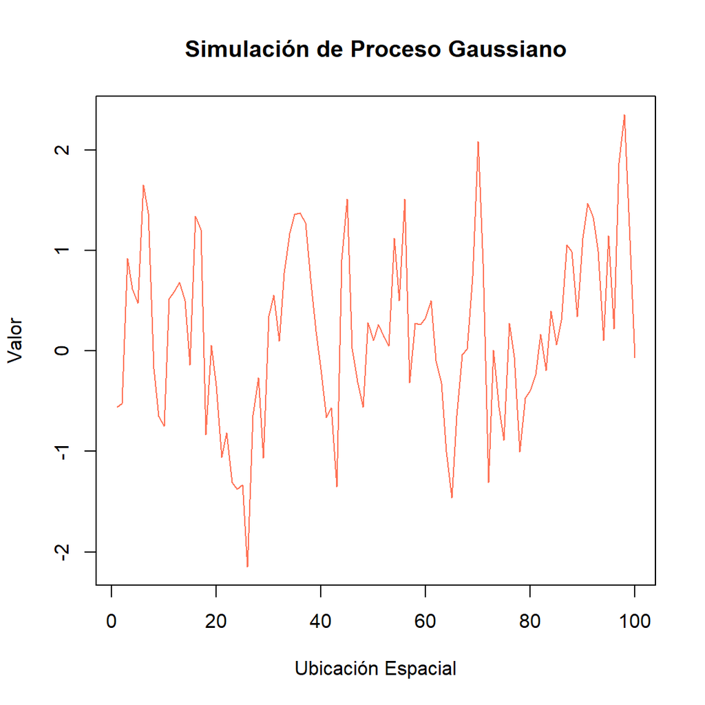

# Punto 2

Calcule $\hat{\gamma}(h,\theta)$ el estimador de Matheron (de momentos)

## Estimador de Matheron

El estimador de Matheron para el parámetro de la función de covarianza exponencial puede calcularse utilizando la matriz de covarianza muestral. Para la función de covarianza exponencial, la expresión es la siguiente:

$$\hat{\gamma}(h, \theta) =
\hat{\sigma}^2 \left(1 - \exp\left(-\frac{h}{\hat{\phi}}\right)\right)$$

Donde: - $\hat{\sigma}^2$ es la varianza muestral. - $\hat{\phi}$ es el estimador de Matheron para el parámetro $\phi$.

A continuación, te muestro cómo puedes calcular este estimador en R basándote en el proceso gaussiano simulado anteriormente:

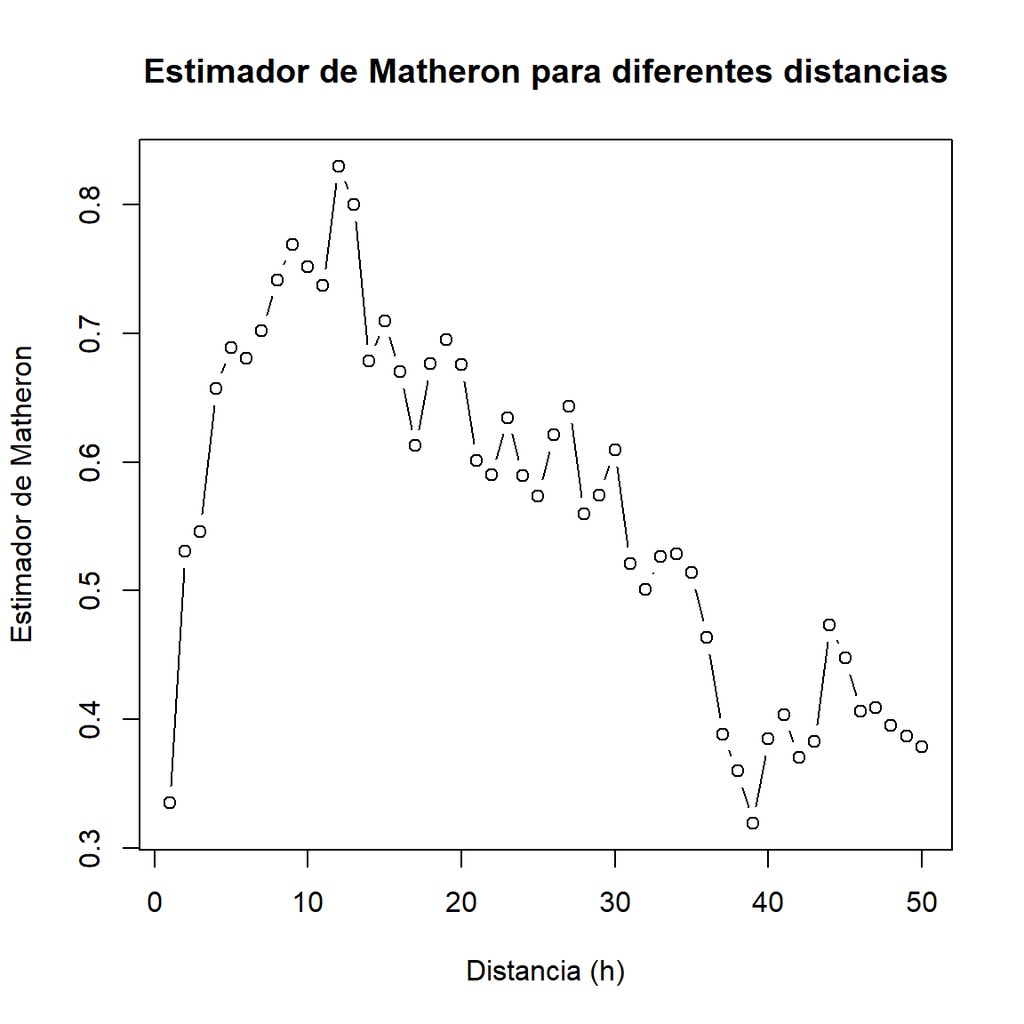

```r
# Calcular estimador de Matheron para diferentes distancias h
distancias_h <- 1:50

resultados_matheron <- numeric(length(distancias_h))  # Vector para almacenar resultados

estimador_matheron <- function(datos, h) {
  n <- length(datos)
  suma <- 0
  for (i in 1:(n - h)) {
    suma <- suma + (datos[i] - datos[i + h])^2}
  return((1 / (2 * (n-1)))*suma)}


# Calcular estimador de Matheron para cada h
for (i in seq_along(distancias_h)) {
  resultado_matheron <- estimador_matheron(simulated_data, distancias_h[i])
  resultados_matheron[i] <- resultado_matheron
}

# Graficar resultados
plot(distancias_h, resultados_matheron, type = "b",
     main = "Estimador de Matheron para diferentes distancias",
     xlab = "Distancia (h)", ylab = "Estimador de Matheron")
```

# Punto 3

Revise la teoría de la función $\texttt{optim}$ de R

## Teoría de la función `optim` en R

La función `optim` en R se utiliza para realizar optimización numérica, es decir, encontrar el mínimo (o máximo) de una función objetivo. La optimización numérica es comúnmente utilizada en áreas donde es necesario ajustar parámetros para que una función se ajuste mejor a datos observados.

## Sintaxis básica de `optim`:

La sintaxis básica de `optim` es la siguiente:

```r
optim(par, fn, ...)
```

- `par`Vector inicial de parámetros
- `fn` Función que se busca minimizar
- `...` Otros argumentos (por ejemplo si se quiere maximizar)

## Ejemplo de Optimización con la Función Cuadrática $f(x) = x^2$

### Definición de la Función Objetivo

Definimos la función cuadrática objetivo $f(x) = x^2$:

```r
# Definir la función objetivo cuadrática
objective_function <- function(x) {
  return(x^2)
}
# Especificar el valor inicial de x
initial_x <- 2

# Aplicar optimización
suppressWarnings(result <- optim(par = initial_x, fn = objective_function))

# Mostrar los resultados
cat("Valor mínimo de x:", result$par, "\n")
```

```
## Valor mínimo de x: -1.776357e-15
```

```r
cat("Valor mínimo de la función:", result$value, "\n")
```

```
## Valor mínimo de la función: 3.155444e-30
```

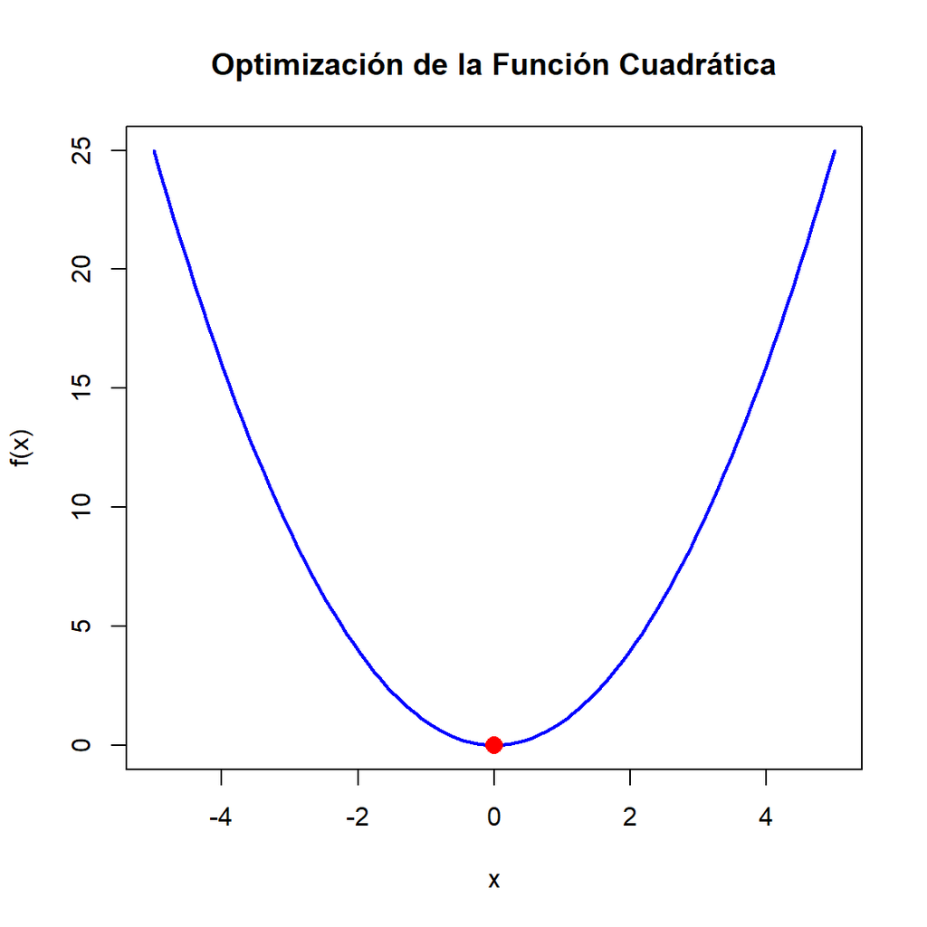

# Punto 4

Use la función $\texttt{optim}$ de R para estimar el modelo de covarianza exponencial (es decir estime $\sigma^2$ y $\phi$ asumiendo un modelo de covarianza exponencial)

```r
# Definir la función objetivo (negativo del logaritmo de la verosimilitud)
neg_log_likelihood <- function(params, data, dist_matrix) {
  sigma_sq <- params[1]
  phi <- params[2]
  n <- length(data)

  # Matriz de covarianza exponencial
  Sigma <- sigma_sq * exp(-dist_matrix / phi)

  # Convertir data en un vector
  data_vector <- as.vector(data)

  # Logaritmo de la verosimilitud
  log_likelihood <- -0.5 * log(det(Sigma)) - 0.5 * t(data_vector) %*% solve(Sigma) %*% data_vector

  return(-log_likelihood)  # Negativo del logaritmo de la verosimilitud
}

# Datos y matriz de distancias
data <- as.matrix(simulated_data)

# Parámetros iniciales y restricciones
initial_params <- c(1, 1)  # Valores iniciales de los parámetros
lower_bound <- c(0, 0)      # Límites inferiores para los parámetros
upper_bound <- c(Inf, Inf)   # Límites superiores para los parámetros

# Optimización usando optim
optimal_params <- optim(par = initial_params, fn = neg_log_likelihood,
                        data = data, dist_matrix = dist_matrix,
                        method = "L-BFGS-B", lower = lower_bound, upper = upper_bound)$par
```

## Párametros estimados

```r
# Imprimir resultados
cat("Estimación de sigma^2:", optimal_params[1], "\n")
```

```
## Estimación de sigma^2: 0.7911266
```

```r
cat("Estimación de phi:", optimal_params[2], "\n")
```

```
## Estimación de phi: 1.827889
```